# Screening Multiple Models for Predicting Volcanic Explosivity Index (VEI)

Yasin Khadem Charvadeh

In this analysis, I utilize a #TidyTuesday dataset on volcanic eruptions to evaluate multiple modeling approaches with the objective of identifying the algorithm with optimal predictive performance. Model comparison is a valuable methodology applied primarily when prior knowledge about which approach might yield superior accuracy on unseen data is limited. Here, I implement various preprocessing tools, including natural language processing methods and Adaptive Synthetic (ADASYN) sampling to prepare the dataset, and experiment with diverse algorithms such as support vector machines, naive Bayes classifiers, ensemble tree methods, and neural networks.

## Download and explore the data

```r
library(tidytuesdayR)
library(textclean)
library(tidyverse)
library(ggrepel)
library(tidymodels)
library(textrecipes)
library(themis)
library(discrim)
library(finetune)
library(naivebayes)

tidymodels_prefer()

tuesdata <- tidytuesdayR::tt_load('2020-05-12')
volcano <- tuesdata$volcano

eruptions <- tuesdata$eruptions


## Create a categorical outcome variable using VEI score

## Non_Gen stands for non-explosive and gentle

## Exp_Sev stands for explosive and severe

## Very_large category includes cataclysmic, paroxysmal, colossal, super-colossal, and mega-colossal

eruptions_w <- eruptions %>% transmute(
    volcano_number,
    vei,
    vei_cat = case_when(
        vei <= 1 ~ 'Non_Gen',
        vei >= 2 &
            vei <= 3 ~ 'Exp_Sev',
        vei >= 4 ~ 'Very_large'
    )
)

## Select the variables of interest

volcano_w <-
    volcano %>% select(
        volcano_number,
        country,
        latitude,
        longitude,
        elevation,
        tectonic_settings,
        major_rock_1,
        major_rock_2,
        major_rock_3,
        major_rock_4,
        major_rock_5
    )
```

We will clean the variables $\textit{major_rock_1}$, $\textit{major_rock_2}$, $\textit{major_rock_3}$, $\textit{major_rock_4}$, $\textit{major_rock_5}$ to be combined together later.

```r
volcano_w <- volcano_w %>% mutate(
    major_rock_1 =
        replace_white(str_replace(
            paste(
                map(major_rock_1,
                    ~ strsplit(.x, '/', fixed = TRUE)) %>%
                    map_chr( ~ str_replace_all(trimws(.x[[1]][2]),
                                               c(
                                                   ' ' = '_', '-' = '_'
                                               ))),
                map(major_rock_1,
                    ~ strsplit(.x, '/', fixed = TRUE)) %>%
                    map_chr( ~ .x[[1]][1])
            ), 'NA', ''
        )),
    major_rock_2 =
        replace_white(str_replace(
            paste(
                map(major_rock_2,
                    ~ strsplit(.x, '/', fixed = TRUE)) %>%
                    map_chr( ~ str_replace_all(trimws(.x[[1]][2]),
                                               c(
                                                   ' ' = '_', '-' = '_'
                                               ))),
                map(major_rock_2,
                    ~ strsplit(.x, '/', fixed = TRUE)) %>%
                    map_chr( ~ .x[[1]][1])
            ), 'NA', ''
        )),
    major_rock_3 =
        replace_white(str_replace(
            paste(
                map(major_rock_3,
                    ~ strsplit(.x, '/', fixed = TRUE)) %>%
                    map_chr( ~ str_replace_all(trimws(.x[[1]][2]),
                                               c(
                                                   ' ' = '_', '-' = '_'
                                               ))),
                map(major_rock_3,
                    ~ strsplit(.x, '/', fixed = TRUE)) %>%
                    map_chr( ~ .x[[1]][1])
            ), 'NA', ''
        )),
    major_rock_4 =
        replace_white(str_replace(
            paste(
                map(major_rock_4,
                    ~ strsplit(.x, '/', fixed = TRUE)) %>%
                    map_chr( ~ str_replace_all(trimws(.x[[1]][2]),
                                               c(
                                                   ' ' = '_', '-' = '_'
                                               ))),
                map(major_rock_4,
                    ~ strsplit(.x, '/', fixed = TRUE)) %>%
                    map_chr( ~ .x[[1]][1])
            ), 'NA', ''
        )),
    major_rock_5 =
        replace_white(str_replace(
            paste(
                map(major_rock_5,
                    ~ strsplit(.x, '/', fixed = TRUE)) %>%
                    map_chr( ~ str_replace_all(trimws(.x[[1]][2]),
                                               c(
                                                   ' ' = '_', '-' = '_'
                                               ))),
                map(major_rock_5,
                    ~ strsplit(.x, '/', fixed = TRUE)) %>%
                    map_chr( ~ .x[[1]][1])
            ), 'NA', ''
        ))

)

## Join the two data sets together

full_data <- eruptions_w %>% left_join(volcano_w, by = 'volcano_number')

full_data <- full_data %>% drop_na() %>% unite(
    "rock_type",
    c(major_rock_1, major_rock_2,
      major_rock_3, major_rock_4,
      major_rock_5), remove = TRUE, sep = " "
    ) %>% mutate(vei_cat = as_factor(vei_cat),
                 tectonic_settings = as_factor(tectonic_settings),
                 rock_type = replace_white(str_trim(rock_type)))

full_data %>% glimpse()
```

```
## Rows: 7,160
## Columns: 9
## $ volcano_number    <dbl> 241040, 290240, 263310, 256010, 357040, 282050, 2680~
## $ vei               <dbl> 2, 2, 2, 2, 1, 3, 1, 3, 1, 2, 1, 1, 2, 1, 2, 1, 3, 3~
## $ vei_cat           <fct> Exp_Sev, Exp_Sev, Exp_Sev, Exp_Sev, Non_Gen, Exp_Sev~
## $ country           <chr> "New Zealand", "Russia", "Indonesia", "Solomon Islan~
## $ latitude          <dbl> -37.520, 48.092, -7.942, -10.386, -35.223, 30.443, 0~
## $ longitude         <dbl> 177.180, 153.200, 112.950, 165.804, -70.568, 130.217~
## $ elevation         <dbl> 294, 1496, 2329, 796, 3977, 657, 1715, 1785, 1172, 1~
## $ tectonic_settings <fct> Subduction zone / Continental crust (>25 km), Subduc~
## $ rock_type         <chr> "Basaltic_Andesite Andesite Dacite", "Basaltic_Andes~
```

## Exploratory Data Analysis

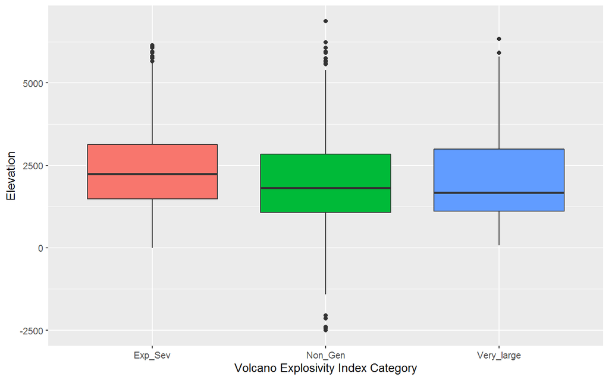

```r
full_data %>% ggplot() +
    geom_boxplot(aes(y = elevation, x = vei_cat, fill = vei_cat)) +
    labs(x = 'Volcano Explosivity Index Category', y = 'Elevation') +
    guides(fill = 'none')
```

Following graph displays a map of the volcanoes locations with their respective VEI category.

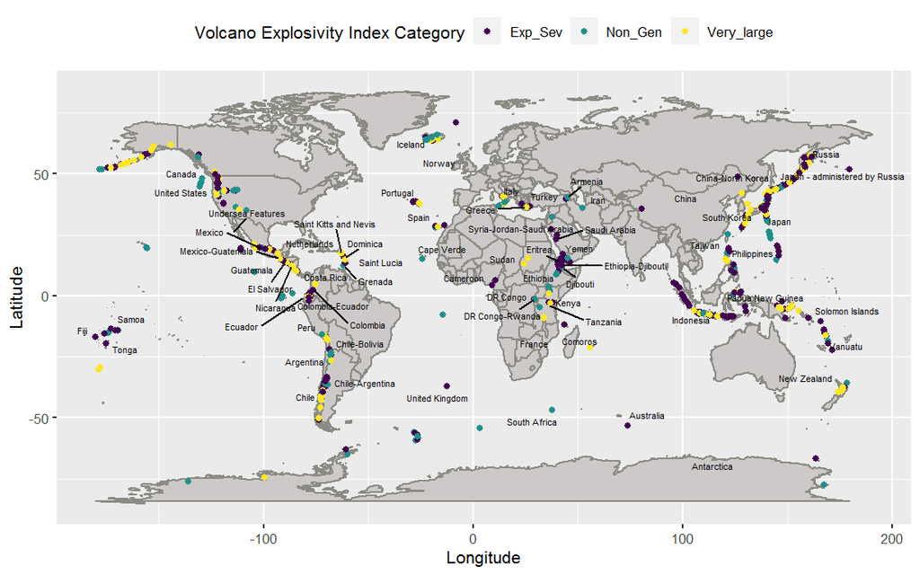

```r
worl_data <- map_data('world')

country_name <- full_data %>% group_by(country) %>%
    summarise(long = mean(longitude), lat = mean(latitude))

worl_data %>% ggplot(aes(long, lat)) +
    geom_map(map = worl_data,
             aes(map_id = region),
             colour = '#8B8B83',
             fill = '#CDC9C9') +
    geom_point(data = full_data, aes(longitude, latitude, color = vei_cat)) +
    geom_text_repel(
        data = country_name,
        aes(label = country),
        size = 2,
        max.overlaps = getOption("ggrepel.max.overlaps", default = 20),
        color = 'gray1'
    ) +
    labs(color = 'Volcano Explosivity Index Category',
         x = 'Longitude', y = 'Latitude') + theme(legend.position = 'top') +
  scale_color_viridis_d()
```

## Pre-processing and Modelling

- Data splitting

```r
set.seed(101)

split_data <- initial_split(full_data, strata = vei_cat)

data_train <- training(split_data)

data_test <- testing(split_data)

set.seed(201)

vol_folds <- vfold_cv(data_train, strata = vei_cat)
```

- Data preprocessing and feature engineering

```r
models_rec <- recipe(vei_cat ~ ., data = data_train) %>%
  update_role(volcano_number, new_role = 'id variable') %>%
  update_role(vei, new_role = 'numeric vei') %>%
  update_role(country, new_role = 'country name') %>%
  step_normalize(latitude, longitude, elevation) %>%
  step_other(tectonic_settings, threshold = tune()) %>%
  step_dummy(tectonic_settings, one_hot = TRUE) %>%
  step_tokenize(rock_type) %>%
  step_tf(rock_type) %>%
  step_adasyn(vei_cat, over_ratio = tune()) %>%
  step_tomek(vei_cat)
```

- Model specification

```r
dec_tree_spec <-
  decision_tree(cost_complexity = tune(),
                min_n = tune()) %>%
  set_engine("rpart") %>%
  set_mode("classification")

rf_spec <-
  rand_forest(mtry = tune(),
              min_n = tune(),
              trees = 2000) %>%
  set_engine("ranger") %>%
  set_mode("classification")

nb_spec <-
  naive_Bayes(smoothness = tune(),
              Laplace = tune()) %>%
  set_engine("klaR") %>%
  set_mode("classification")

xgb_spec <-
  boost_tree(
    tree_depth = tune(),
    trees = tune(),
    learn_rate = tune(),
    mtry = tune(),
    min_n = tune(),
    loss_reduction = tune(),
    sample_size = tune()
  ) %>%
  set_engine("xgboost") %>%
  set_mode("classification")

nnet_spec <-
  mlp(hidden_units = tune(),
      penalty = tune(),
      epochs = tune()) %>%
  set_engine("nnet") %>%
  set_mode("classification")

svm_spec <-
  svm_rbf(cost = tune(), rbf_sigma = tune()) %>%
  set_engine("kernlab") %>%
  set_mode("classification")
```

- Creating a workflow set
- Finalizing hyperparameters of some models (if necessary)

```r
models_wf <-
   workflow_set(
      preproc = list(models_recipe = models_rec),
      models = list(random_forest = rf_spec,
                    dec_tree = dec_tree_spec,
                    naive_Bayes_model = nb_spec,
                    neural_network = nnet_spec,
                    SVM_radial = svm_spec,
                    XGBoost = xgb_spec
                    )
   )

models_wf
```

```
## # A workflow set/tibble: 6 x 4
##   wflow_id                        info             option    result
##   <chr>                           <list>           <list>    <list>
## 1 models_recipe_random_forest     <tibble [1 x 4]> <opts[0]> <list [0]>
## 2 models_recipe_dec_tree          <tibble [1 x 4]> <opts[0]> <list [0]>
## 3 models_recipe_naive_Bayes_model <tibble [1 x 4]> <opts[0]> <list [0]>
## 4 models_recipe_neural_network    <tibble [1 x 4]> <opts[0]> <list [0]>
## 5 models_recipe_SVM_radial        <tibble [1 x 4]> <opts[0]> <list [0]>
## 6 models_recipe_XGBoost           <tibble [1 x 4]> <opts[0]> <list [0]>
```

```r
models_wf <-
  models_wf %>%
  mutate(wflow_id = str_remove(wflow_id, 'models_recipe_'))

updated_param_rf <-
  models_wf %>%
  extract_parameter_set_dials(id = 'random_forest') %>%
  finalize(data_train)

updated_param_XGB <-
  models_wf %>%
  extract_parameter_set_dials(id = 'XGBoost') %>%
  finalize(data_train)

models_wf <-
   models_wf %>%
   option_add(param_info = updated_param_rf, id = 'random_forest')

models_wf <-
   models_wf %>%
   option_add(param_info = updated_param_XGB, id = 'XGBoost')


models_wf
```

```
## # A workflow set/tibble: 6 x 4
##   wflow_id          info             option    result
##   <chr>             <list>           <list>    <list>
## 1 random_forest     <tibble [1 x 4]> <opts[1]> <list [0]>
## 2 dec_tree          <tibble [1 x 4]> <opts[0]> <list [0]>
## 3 naive_Bayes_model <tibble [1 x 4]> <opts[0]> <list [0]>
## 4 neural_network    <tibble [1 x 4]> <opts[0]> <list [0]>
## 5 SVM_radial        <tibble [1 x 4]> <opts[0]> <list [0]>
## 6 XGBoost           <tibble [1 x 4]> <opts[1]> <list [0]>
```

- Tuning and evaluating the models

```r
race_ctrl <-
   control_race(
     save_workflow = TRUE,
     save_pred = TRUE,
     parallel_over = "resamples"
   )

cls_metrics <- metric_set(accuracy, roc_auc)

race_results <-
   models_wf %>%
   workflow_map(
      "tune_race_anova",
      seed = 250,
      resamples = vol_folds,
      grid = 20,
      metrics = cls_metrics,
      control = race_ctrl
   )
```

- Screening models to find the best model

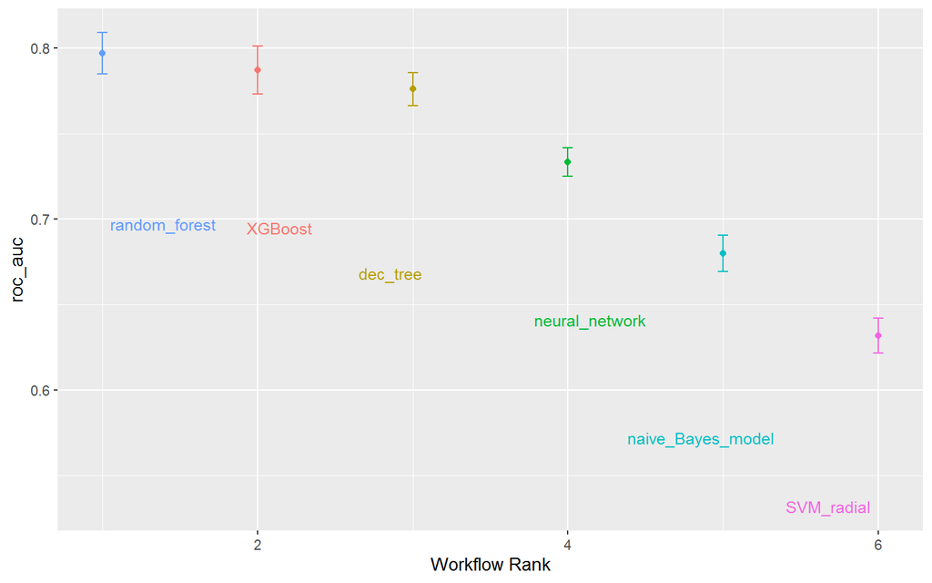

```r
autoplot(
   race_results,
   rank_metric = "roc_auc",
   metric = "roc_auc",
   select_best = TRUE
) +
   geom_text_repel(aes(y = mean - 0.1, label = wflow_id), size = 3.5) +
   theme(legend.position = "none")
```

```r
best_para <-
  race_results %>%
  extract_workflow_set_result('random_forest') %>%
  select_best(metric = 'roc_auc')

best_para
```

```
## # A tibble: 1 x 6
##   .order  mtry min_n threshold over_ratio .config
##    <int> <int> <int>     <dbl>      <dbl> <chr>
## 1      4     9    24    0.0810      0.860 Preprocessor20_Model1
```

```r
final_fit <-
  race_results %>%
  extract_workflow('random_forest') %>%
  finalize_workflow(best_para) %>%
  last_fit(split_data)
```

```r
collect_metrics(final_fit)
```

```
## # A tibble: 2 x 4
##   .metric  .estimator .estimate .config
##   <chr>    <chr>          <dbl> <chr>
## 1 accuracy multiclass     0.637 Preprocessor1_Model1
## 2 roc_auc  hand_till      0.811 Preprocessor1_Model1
```

```r
lf_pred <- collect_predictions(final_fit)

lf_pred
```

```
## # A tibble: 1,791 x 8
##    id     .pred_Exp_Sev .pred_Non_Gen .pred_Very_large  .row .pred_class vei_cat
##    <chr>          <dbl>         <dbl>            <dbl> <int> <fct>       <fct>
##  1 train~         0.518         0.306          0.176       5 Exp_Sev     Non_Gen
##  2 train~         0.754         0.162          0.0840     10 Exp_Sev     Exp_Sev
##  3 train~         0.668         0.209          0.124      11 Exp_Sev     Non_Gen
##  4 train~         0.692         0.301          0.00703    29 Exp_Sev     Exp_Sev
##  5 train~         0.742         0.250          0.00749    31 Exp_Sev     Non_Gen
##  6 train~         0.481         0.514          0.00524    37 Non_Gen     Non_Gen
##  7 train~         0.696         0.221          0.0829     38 Exp_Sev     Exp_Sev
##  8 train~         0.389         0.606          0.00584    40 Non_Gen     Non_Gen
##  9 train~         0.326         0.221          0.453      50 Very_large  Non_Gen
## 10 train~         0.114         0.669          0.217      57 Non_Gen     Exp_Sev
## # ... with 1,781 more rows, and 1 more variable: .config <chr>
```

```r
## Confusion matrix

conf_mat(lf_pred, truth = vei_cat, estimate = .pred_class)
```

```
##             Truth
## Prediction   Exp_Sev Non_Gen Very_large
##   Exp_Sev        746     148         46
##   Non_Gen        207     291         16
##   Very_large     178      56        103
```

```r
## Matthews correlation coefficient (MCC): MCC produces a more informative and truthful score in evaluating classification models

mcc(lf_pred, truth = vei_cat, estimate = .pred_class)
```

```
## # A tibble: 1 x 3
##   .metric .estimator .estimate
##   <chr>   <chr>          <dbl>
## 1 mcc     multiclass     0.372
```

```r
sensitivity(lf_pred, truth = vei_cat, estimate = .pred_class,
            estimator = "micro")
```

```
## # A tibble: 1 x 3
##   .metric     .estimator .estimate
##   <chr>       <chr>          <dbl>
## 1 sensitivity micro          0.637
```

The model's performance is clearly unsatisfactory, which was anticipated due to two main factors: (1) the dataset is unbalanced, and even applying the ADASYN algorithm yielded only limited improvement; (2) the dataset contains relatively few predictors. Collecting additional data and expanding the set of predictors would likely enhance the model's performance.